# OncoImplexus Analysis Report: Sample

January 20, 2026

# Executive Summary

### Automated Findings Overview

In sample **DO17373**, we identified **3 high-confidence Chromothripsis** event(s). Critical analysis reveals impact on key driver genes, including **BCL2L11, MERTK, CENPA**. The genomic background is dominated by **NHEJ** repair signatures, with a median microhomology of 0 bp.

This report summarizes the complex chromosomal rearrangements detected in **DO17373**.

Summary of Detected Events

| Metric | Count | Status |
| --- | --- | --- |
| Chromothripsis (High Conf) | 3 | Detected |
| Chromothripsis (Low Conf) | 0 | Not Detected |
| Chromoplexy (Likely) | 0 | Not Detected |
| Chromoplexy (Possible) | 277 | Detected |
| Chromoanasynthesis (Likely) | 0 | Not Detected |
| Chromoanasynthesis (Possible) | 6 | Detected |

# Genomic Landscape Dashboard

This dashboard provides a multi-panel overview of structural variants, copy number profiles, and the distribution of detected chromoanagenesis events.

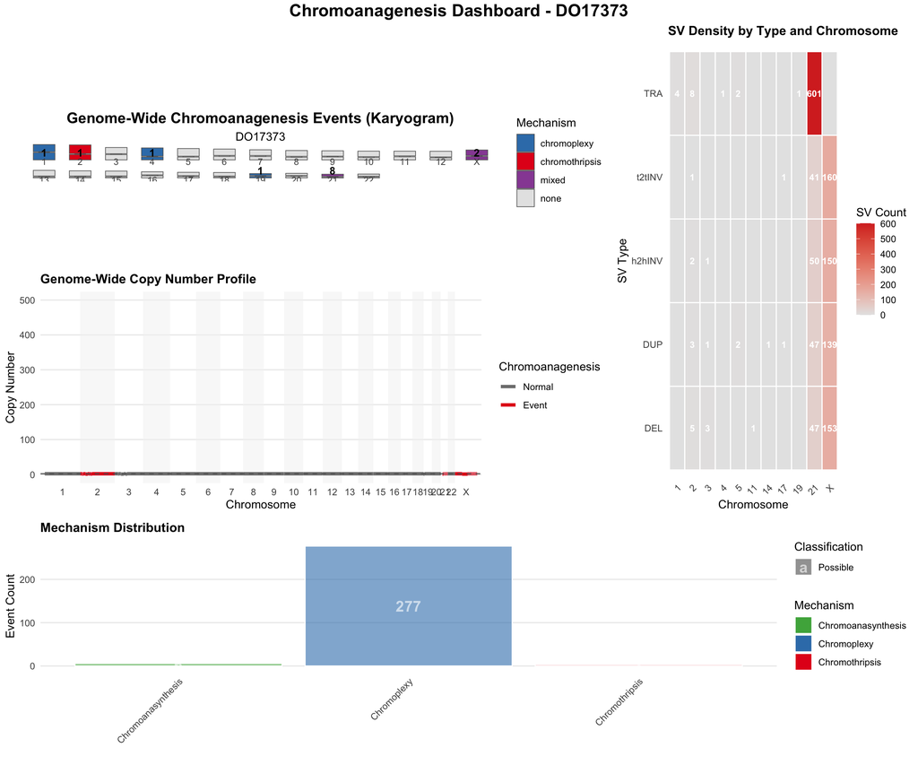

# Genome-Wide Visualization

This Circos plot integrates copy number variations (outer ring), detected chromoanagenesis regions (colored bands), and structural variant links.

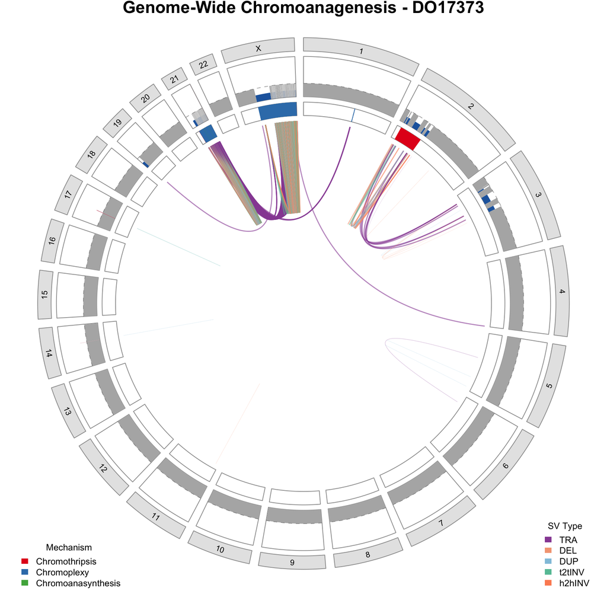

# Functional Impact & Biological Insights

## 1. Driver Gene Impact

Analysis of cancer driver genes potentially impacted by the detected mechanisms.

|  | Gene | Gene_Type | Mechanism | Impact_Type | Mechanism_Consistency | Region |
| --- | --- | --- | --- | --- | --- | --- |
| 27 | BCL2L11 | TSG | Chromothripsis | Region_Overlap | Consistent (TSG Loss) | chr2:1-500000000 |
| 167 | MERTK | ONCOGENE | Chromothripsis | Region_Overlap | Potential Fusion/Disruption | chr2:1-500000000 |
| 174 | CENPA | INSUFFICIENT_EVIDENCE | Chromothripsis | Region_Overlap | Indeterminate | chr2:1-500000000 |
| 187 | MTHFD2 | ONCOGENE | Chromothripsis | Region_Overlap | Potential Fusion/Disruption | chr2:1-500000000 |
| 188 | ARID5A | INSUFFICIENT_EVIDENCE | Chromothripsis | Region_Overlap | Indeterminate | chr2:1-500000000 |
| 206 | CHN1 |  | Chromothripsis | Region_Overlap | Indeterminate | chr2:1-500000000 |
| 210 | SP140 | TSG | Chromothripsis | Region_Overlap | Consistent (TSG Loss) | chr2:1-500000000 |
| 253 | DIS3L2 | ONCOGENE_AND_TSG | Chromothripsis | Region_Overlap | Consistent (TSG Loss) | chr2:1-500000000 |
| 301 | CPS1 |  | Chromothripsis | Region_Overlap | Indeterminate | chr2:1-500000000 |
| 302 | CREB1 | ONCOGENE | Chromothripsis | Region_Overlap | Potential Fusion/Disruption | chr2:1-500000000 |

[output cut: 124 more lines]

- **Consistent (TSG Loss)**: Tumor Suppressor Genes (TSGs) are disrupted or lost. This aligns with biological expectations as catastrophes typically lead to loss of gene function.
- **Consistent (Oncogene Amp)**: Oncogenes are amplified. This indicates that catastrophe events (e.g., Chromoanasynthesis) generated multiple copies, thereby activating the oncogene.
- **Potential Fusion/Disruption**: Potential gene fusion or structural disruption. For oncogenes, this may indicate the creation of a pathogenic fusion gene; for others, it represents a direct structural break.
- **Inconsistent (TSG Amp)**: Inconsistent status. A tumor suppressor gene is amplified, which is rare in tumor evolution and may not be the primary driver of this specific event.

## 2. Predicted Fusion Genes & Disruptions

Potential oncogenic fusion events or gene disruptions created by structural rearrangements.

|  | fusion_name | type | status | sv_type | orientation_compatible | sequence_preview |
| --- | --- | --- | --- | --- | --- | --- |
| 1 | ZNF280C::GPC3 | Fusion | Non-canonical (Intronic) | t2tINV | False | ACACGCCACCACGCCC\|AGCCTTGGTCAGAAA |
| 2 | RUNX1::ERG | Fusion | Non-canonical (Intronic) | t2tINV | False | AGCACTGTGCCTGGTA\|TCTGTATGCTCACGG |
| 3 | CHODL-AS1::GAB3 | Fusion | Non-canonical (Intronic) | TRA | False | CCTTATATAGGACAGT\|AGACATATATGTACA |
| 4 | KCNJ15::PRMT2 | Fusion | Non-canonical (Intronic) | h2hINV | False | TAGTTGAGGAACCCC\|GGTCTTGTGTCTTTT |
| 5 | CHODL::GUCY2F | Fusion | Non-canonical (Intronic) | TRA | False | AGCTCACTGCAACCT\|AGGCTGAGGTATGCT |
| 6 | GABPA::IL10RB | Fusion | Non-canonical (Intronic) | h2hINV | False | TTAAACATTGTTTGT\|GTGAGCCACTGTGCT |
| 7 | TSPEAR::XRCC6P5 | Fusion | Non-canonical (Intronic) | TRA | False | GTAGGTGGAGGGATG\|TGATTGCCTCTGCTA |
| 8 | KCNJ6::NSDHL | Fusion | Non-canonical (Intronic) | TRA | False | CCACATTTTACCACAT\|CCCTTTTCTAGCAAT |
| 9 | APP::CFAP298 | Fusion | Non-canonical (Intronic) | t2tINV | False | TTAGTTTCTAATCCA\|AACCATCAGCACCAT |
| 10 | CHODL::GPC3 | Fusion | Non-canonical (Intronic) | TRA | False | TGAAAGGCACTTCTTA\|TCTCTACTAAAAATA |

[output cut: 450 more lines]

- **Canonical (Potential 5’->3’ fusion)**: The SV breakpoints join the 5’ part of one gene to the 3’ part of another in a way that allows for a continuous, functional fusion transcript. This status indicates high oncogenic potential.
- **Non-canonical (Orientation mismatch)**: Breakpoint orientations are incompatible for a standard 5’->3’ fusion (e.g., Head-to-Head or Tail-to-Tail joins). While they unlikely produce a functional fusion protein, they can still lead to gene truncation, loss of function, or enhancer hijacking.
- **Indeterminate**: The fusion potential cannot be accurately determined due to incomplete strand information or complex local rearrangements.

## 3. DNA Repair Mechanisms

Inferred DNA repair pathways (NHEJ, MMEJ, SSA, MMBIR) based on microhomology and insertion signatures at breakpoint junctions.

**[Click to Expand] View DNA Repair & Microhomology Details**

Distribution of Inferred Repair Mechanisms

| Mechanism | Stats Count | Stats Proportion |
| --- | --- | --- |
| MMBIR/FoSTeS | 4 | 0.3% |
| MMEJ | 29 | 2.0% |
| NHEJ | 1393 | 97.7% |

**Dominant Mechanism:** NHEJ  
**Median Microhomology:** 0 bp

#### Repair by SV Type

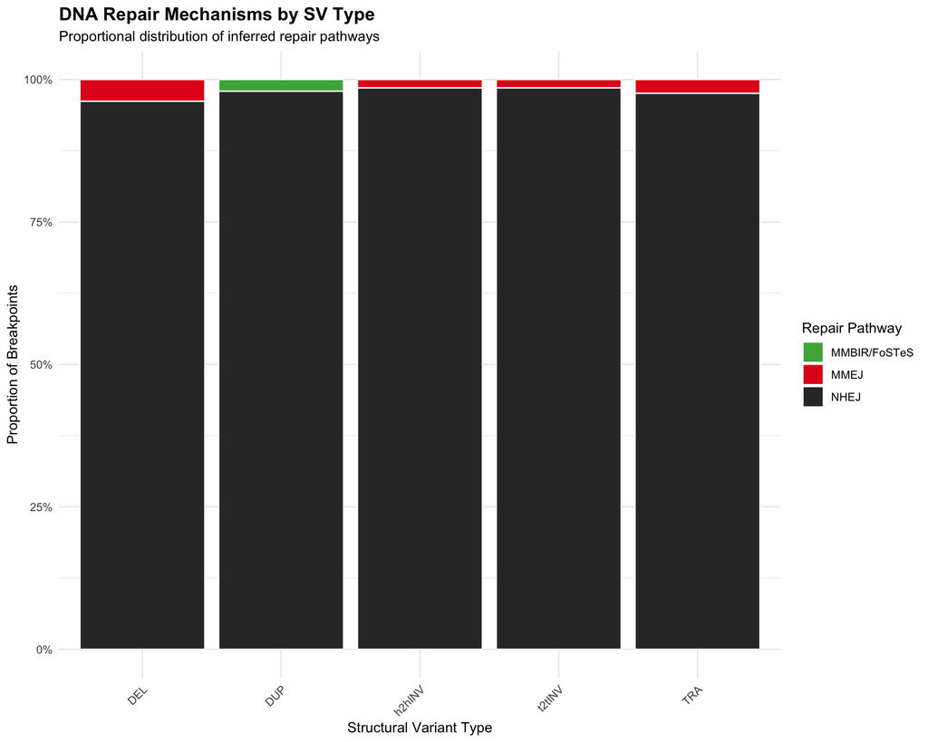

#### Microhomology Distribution

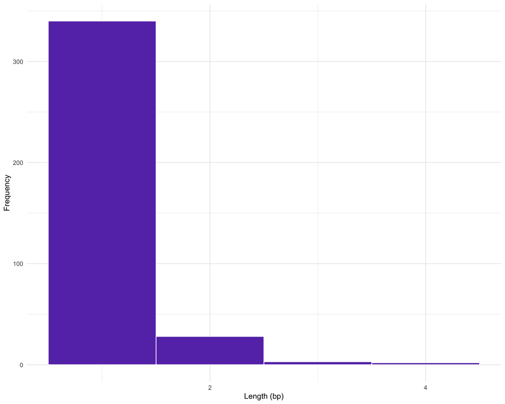

# Detailed Mechanism Findings

## 1. Chromothripsis

Characterized by localized shattering and random joining of DNA fragments.

|  | chrom | classification | confidence_score | clusterSize | repair_signature |
| --- | --- | --- | --- | --- | --- |
| 4 | 2 | High confidence | 1 | 8 | NHEJ (100%) |
| 5 | 21 | High confidence | 1 | 183 | NHEJ (96%), MMEJ (3%) |
| 8 | X | High confidence | 1 | 594 | NHEJ (98%), MMEJ (1%) |
| 6 | 3 | Not chromothripsis | 1 | 2 | NHEJ (100%) |
| 7 | 5 | Not chromothripsis | 0.37 | 1 | NHEJ (100%) |
| 1 | 11 | Not chromothripsis | 0.22 | 1 | NHEJ (100%) |
| 2 | 14 | Not chromothripsis | 0.22 | 1 | NHEJ (100%) |
| 3 | 17 | Not chromothripsis | 0.22 | 1 | NHEJ (100%) |

## 2. Chromoplexy

Characterized by chained translocations across multiple chromosomes.

|  | chain_id | n_chromosomes | n_translocations | classification | repair_signature | combined_score |
| --- | --- | --- | --- | --- | --- | --- |
| 192 | 192 | 3 | 4 | Possible chromoplexy | NHEJ (100%) | 0.41 |
| 193 | 193 | 3 | 4 | Possible chromoplexy | NHEJ (100%) | 0.41 |
| 194 | 194 | 3 | 4 | Possible chromoplexy | NHEJ (100%) | 0.41 |
| 195 | 195 | 3 | 4 | Possible chromoplexy | NHEJ (80%), MMEJ (20%) | 0.41 |
| 196 | 196 | 3 | 4 | Possible chromoplexy | NHEJ (100%) | 0.41 |
| 197 | 197 | 3 | 4 | Possible chromoplexy | NHEJ (100%) | 0.41 |
| 198 | 198 | 3 | 4 | Possible chromoplexy | NHEJ (100%) | 0.41 |
| 199 | 199 | 3 | 4 | Possible chromoplexy | NHEJ (100%) | 0.41 |
| 200 | 200 | 3 | 4 | Possible chromoplexy | NHEJ (100%) | 0.41 |
| 201 | 201 | 3 | 4 | Possible chromoplexy | NHEJ (100%) | 0.41 |

[output cut: 267 more lines]

## 3. Chromoanasynthesis

Characterized by replication-based mechanisms (FoSTeS) with copy number gradients.

|  | region_id | chrom | start | end | classification | max_chain_length | repair_signature |
| --- | --- | --- | --- | --- | --- | --- | --- |
| rho | 1 | 21 | 19632664 | 19963757 | Unlikely chromoanasynthesis | 0 | NHEJ (95%), MMEJ (5%) |
| rho1 | 2 | 21 | 19720563 | 20060197 | Unlikely chromoanasynthesis | 0 | NHEJ (95%), MMEJ (5%) |
| rho2 | 3 | 21 | 19802169 | 19909714 | Unlikely chromoanasynthesis | 0 | NHEJ (86%), MMEJ (14%) |
| rho3 | 4 | 21 | 19803682 | 19963757 | Unlikely chromoanasynthesis | 0 | NHEJ (89%), MMEJ (11%) |
| rho4 | 5 | 21 | 21767392 | 22694117 | Unlikely chromoanasynthesis | 0 | NHEJ (100%) |
| rho5 | 6 | 21 | 21921317 | 22461216 | Unlikely chromoanasynthesis | 0 | NHEJ (100%) |
| rho6 | 7 | 21 | 21959194 | 22694117 | Unlikely chromoanasynthesis | 0 | NHEJ (100%) |
| rho7 | 8 | 21 | 23259450 | 23348546 | Possible chromoanasynthesis | 0 | NHEJ (100%) |
| rho8 | 9 | 21 | 23286581 | 23352623 | Possible chromoanasynthesis | 0 | NHEJ (100%) |
| rho9 | 10 | 21 | 24691536 | 25385103 | Unlikely chromoanasynthesis | 0 | NHEJ (93%), MMEJ (7%) |

[output cut: 40 more lines]

# Data Diagnostics

## Data Integrity & Noise Assessment

The following metrics assess the quality and consistency of the input SV and CNV data.

Data Diagnostics Metrics

| Metric | Value | Status |
| --- | --- | --- |
| Total SVs | 1426 | OK |
| Inter-chromosomal SV Rate | 43.3% | OK |
| Total CNV Segments | 1117 | OK |
| Avg Segment Size (bp) | 2,703,197 | OK |
| Hyper-segmentation Risk (<10kb) | 27.4% | High Noise |
| SV-CNV Overlap Rate | 99.0% | OK |

**OncoImplexus** Analysis | Generated on 2026-01-20 23:39:49.414279